# Time-to-event

# Objective

Investigate systematic bias with saemix compared to Monolix for TTE model

### Results Alexandra

- simulations avec modèle TTE, risque de base de Weibull, simulations sans IIV
  - a fait tourner deux simulations avec un modèle de Weibull (paramètres $k$ et $l$) et un modèle de covariable ($\times e^{B Cov_i]}$)
    - 1000 sujets et environ 25% d’évènements
    - estimation avec une variabilité sur $l$, distribution log-normales pour les 2 paramètres, effet $\beta$ d’une covariable sur B qui est un paramètre sans variabilité avec une moyenne fixée à 0
      - simulations initiales: avec variabilité sur $k$ ou $\lambda$: biais de 50% sur $k$, -8% sur $\lambda$ et 13% sur $\beta$
      - update avril, biais: $k$ surestimé, $\beta$ sous-estimé (les deux d’environ 20-30%); $l$ légèrement sous-estimé mais seulement de 2-3% a priori
      - résultats similaires quand on met la variabilité sur $k$ au lieu de $l$
    - estimation avec une dummy variable
      - ajout d’une variable sans effet dans le modèle, sur laquelle porte une variabilité
      - là les résultats sont beaucoup mieux, avec seulement 10% de biais sur $k$ et 2-3% sur $\beta$ (à vérifier sur des graphes avec valeurs relatives au lieu)
      - avec dummy variable avec IIV (valeur fixée): biais de 11% sur $k$, -2% sur $\lambda$ et 5% sur $\beta$
- [ ] Eco
  - regarder si en changeant les CI ou les distributions on trouve les mêmes biais
  - essayer aussi en décochant simulated annealing
  - quid du cas sans covariables

# Setup

Directories and libraries

Loading saemix functions

### Code pour la simulation

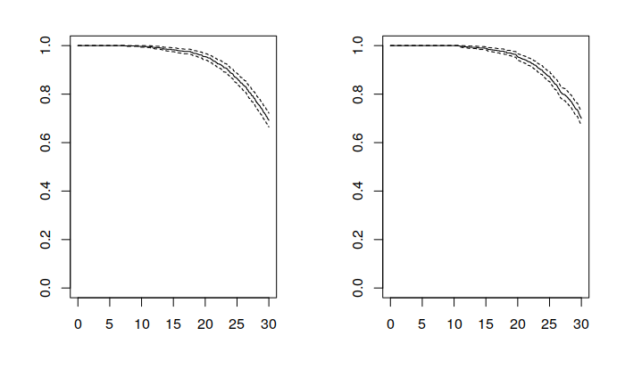

### Running saemix

- results quite close to the simulated values $\Rightarrow$ repeat 100 times to get an idea of the bias

# Bug

- CV=100% in the first model, problem in computation of CV for fixed effects as SE=2.21 and value=37.63 should be CV=5.8%…
  - correct for the random effects, and for the other model => mistake in the show method for a Res object, corrected

```r
tte.fit.age<-saemix(saemix.model.age,saemix.data.age,saemix.options)
```

[output not shown]

[output cut: 946 more lines]

[output not shown]

```
Nonlinear mixed-effects model fit by the SAEM algorithm
-----------------------------------
----          Data             ----
-----------------------------------
Object of class SaemixData
    longitudinal data for use with the SAEM algorithm
Dataset tte.data
    Structured data: ev ~ time + ev + age | id
    X variable for graphs: time (days)
Dataset characteristics:
    number of subjects:     1000
    number of observations: 2000
    average/min/max nb obs: 2.00  /  2  /  2
First 10 lines of data:
```

|  | id | time | ev | age | ev.1 | mdv | cens | occ | ytype |
| --- | --- | --- | --- | --- | --- | --- | --- | --- | --- |
| 1001 | 1 | 0.00000 | 0 | 1 | 0 | 0 | 0 | 1 | 1 |
| 1 | 1 | 30.00000 | 0 | 1 | 0 | 0 | 0 | 1 | 1 |
| 1002 | 2 | 0.00000 | 0 | 2 | 0 | 0 | 0 | 1 | 1 |
| 2 | 2 | 15.12789 | 1 | 2 | 1 | 0 | 0 | 1 | 1 |
| 1003 | 3 | 0.00000 | 0 | 1 | 0 | 0 | 0 | 1 | 1 |
| 3 | 3 | 30.00000 | 0 | 1 | 0 | 0 | 0 | 1 | 1 |
| 1004 | 4 | 0.00000 | 0 | 2 | 0 | 0 | 0 | 1 | 1 |
| 4 | 4 | 30.00000 | 0 | 2 | 0 | 0 | 0 | 1 | 1 |
| 1005 | 5 | 0.00000 | 0 | 2 | 0 | 0 | 0 | 1 | 1 |
| 5 | 5 | 30.00000 | 0 | 2 | 0 | 0 | 0 | 1 | 1 |

```
-----------------------------------
----          Model            ----
-----------------------------------
Nonlinear mixed-effects model
  Model function:  time model
  Model type:  likelihood
function(psi,id,xidep) {
  T<-xidep[,1]
  y<-xidep[,2] # events (1=event, 0=no event)
  age<-xidep[,3]
  cens<-which(T==30 & y==0)
  init <- which(T==0)
  lambda <- psi[id,1] # Parameters of the Weibull model
  beta <- psi[id,2]
  gamma <- psi[id,3]
  Nj <- length(T)

  ind <- setdiff(1:Nj, append(init,cens)) # indices of events
  hazard <- (beta/lambda)*exp(gamma*as.integer(age==2))*(T/lambda)^(beta-1) # ln(H')
  H <- exp(gamma*as.integer(age==2))*(T/lambda)^beta # ln(H)
  logpdf <- rep(0,Nj) # ln(l(T=0))=0
  logpdf[cens] <- -H[cens] + H[cens-1] # ln(l(T=censoring time)) # term gamma*as.integer(age==2) cancels itself ?
  logpdf[ind] <- -H[ind] + H[ind-1] + log(hazard[ind]) # ln(l(T=event time))
  return(logpdf)
}
<bytecode: 0x55f71d674b30>
  Nb of parameters: 3
      parameter names:  lambda beta gamma
      distribution:
     Parameter Distribution Estimated
[1,] lambda    log-normal   Estimated
[2,] beta      log-normal   Estimated
[3,] gamma     normal       Estimated
  Variance-covariance matrix:
       lambda beta gamma
lambda      1    0     0
beta        0    0     0
gamma       0    0     0
    No covariate in the model.
    Initial values
```

[output cut: 35 more lines]

```
              omega2.lambda
omega2.lambda 1
----------------------------------------------------
---------------  Statistical criteria  -------------
----------------------------------------------------
Likelihood computed by linearisation
      -2LL= 5698.971
      AIC = 5708.971
      BIC = 5733.51

Likelihood computed by importance sampling
      -2LL= 2852.733
      AIC = 2862.733
      BIC = 2887.272
----------------------------------------------------
```